# Data Visualization Using Pandas and Matplotlib

### Preparing Data

```python
%matplotlib inline
#sns.set_context('notebook')
%config InlineBackend.figure_format = 'retina'
```

```python
import seaborn as sns
import pandas as pd
import matplotlib.pyplot as plt
df = pd.read_excel("https://github.com/chris1610/pbpython/blob/master/data/sample-salesv3.xlsx?raw=true")
df.shape
```

```
(1500, 7)
```

```python
df.head()
```

|  | account number | name | sku | quantity | unit price | ext price | date |
| --- | --- | --- | --- | --- | --- | --- | --- |
| 0 | 740150 | Barton LLC | B1-20000 | 39 | 86.69 | 3380.91 | 2014-01-01 07:21:51 |
| 1 | 714466 | Trantow-Barrows | S2-77896 | -1 | 63.16 | -63.16 | 2014-01-01 10:00:47 |
| 2 | 218895 | Kulas Inc | B1-69924 | 23 | 90.70 | 2086.10 | 2014-01-01 13:24:58 |
| 3 | 307599 | Kassulke, Ondricka and Metz | S1-65481 | 41 | 21.05 | 863.05 | 2014-01-01 15:05:22 |
| 4 | 412290 | Jerde-Hilpert | S2-34077 | 6 | 83.21 | 499.26 | 2014-01-01 23:26:55 |

```python
df['date'] = pd.to_datetime(df['date'])
df.rename(columns={'date':'datetime'},inplace=True)
df['month'] = df['datetime'].apply(lambda x: x.month)
df.head()
```

|  | account number | name | sku | quantity | unit price | ext price | datetime | month |
| --- | --- | --- | --- | --- | --- | --- | --- | --- |
| 0 | 740150 | Barton LLC | B1-20000 | 39 | 86.69 | 3380.91 | 2014-01-01 07:21:51 | 1 |
| 1 | 714466 | Trantow-Barrows | S2-77896 | -1 | 63.16 | -63.16 | 2014-01-01 10:00:47 | 1 |
| 2 | 218895 | Kulas Inc | B1-69924 | 23 | 90.70 | 2086.10 | 2014-01-01 13:24:58 | 1 |
| 3 | 307599 | Kassulke, Ondricka and Metz | S1-65481 | 41 | 21.05 | 863.05 | 2014-01-01 15:05:22 | 1 |
| 4 | 412290 | Jerde-Hilpert | S2-34077 | 6 | 83.21 | 499.26 | 2014-01-01 23:26:55 | 1 |

The data contains 1,500 records and 7 variables. I’m going to summarize the data so we can see the total number of purchases and total sales for the top 10 customers.

```python
data = (df.groupby('name')['quantity','ext price'].sum()).sort_values(by='ext price', ascending=False)[:10].reset_index()

data.rename(columns={'name':'Name','ext price':'Sales','quantity':'Quantity'},inplace=True)
```

```python
data
```

|  | Name | Quantity | Sales |
| --- | --- | --- | --- |
| 0 | Kulas Inc | 2265 | 137351.96 |
| 1 | White-Trantow | 2258 | 135841.99 |
| 2 | Trantow-Barrows | 2271 | 123381.38 |
| 3 | Jerde-Hilpert | 1999 | 112591.43 |
| 4 | Fritsch, Russel and Anderson | 2112 | 112214.71 |
| 5 | Barton LLC | 2041 | 109438.50 |
| 6 | Will LLC | 1828 | 104437.60 |
| 7 | Koepp Ltd | 1790 | 103660.54 |
| 8 | Frami, Hills and Schmidt | 1903 | 103569.59 |
| 9 | Keeling LLC | 1806 | 100934.30 |

### Getting Started

#### Create a figure with data

We first use `plt.subplots()` to create two objects: a figure object that is used to be a container that holds everything in the page; an axes object that is used to hold the data.

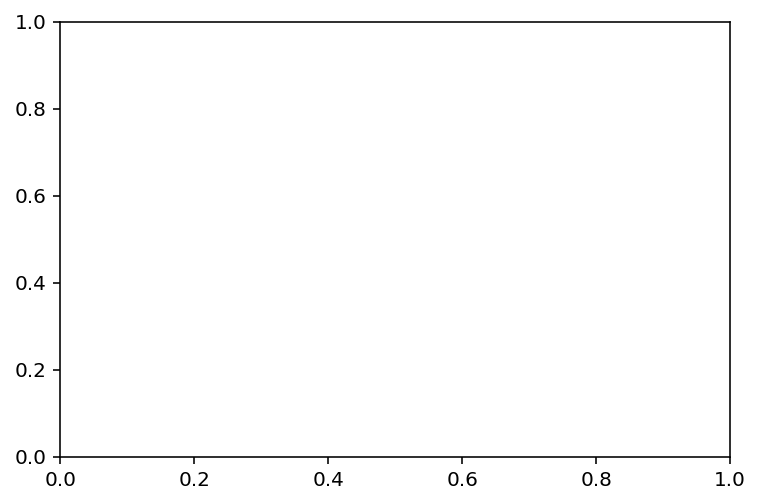

```python
fig, ax = plt.subplots()
```

Then, we put data into the axes.

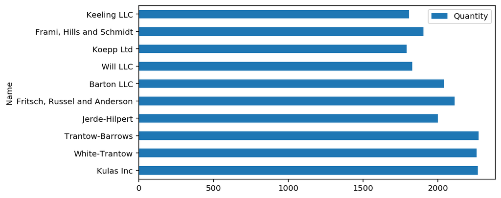

```python
data.plot(x = 'Name',y = 'Quantity',kind='barh',figsize=(8,4),ax=ax)
fig
```

```python
#ax = plt.gca()
#fig, ax = plt.subplots()
#ax.yaxis.set_label_coords(-0.1,1.05)
#ax.set_ylabel('abc', rotation=0, fontsize=10, labelpad=20)
#ax.set_ylabel(ylabel="name",rotation=90)
```

#### Customizing Graph Appearence

##### Marker

The plot method takes in optional key word argument, `marker`, which lets you indicate that you are interested in adding markers to the plot and also what kind of marker you would like. Below is an example with a `circle` marker and all markers available are shown [here](https://matplotlib.org/api/markers_api.html).

```python
data_time = df.groupby('month')['ext price'].mean().reset_index()
```

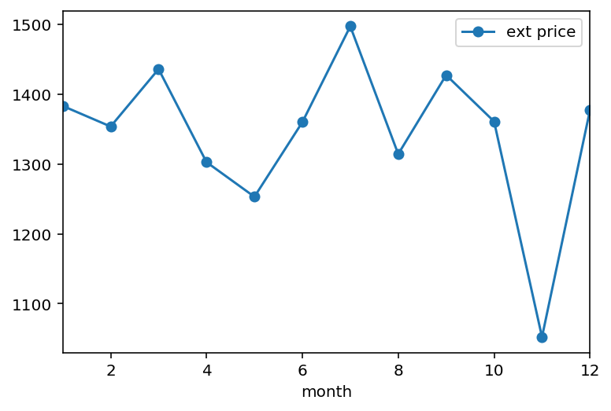

```python
data_time.plot(x='month', y='ext price',kind='line',marker='o')
```

##### Linestyle

When you have two lines in the same axes, you may need to change the line style to distinguish them. Like `marker`, `linestyle` is another optional key word argument in `plot` method. Below is an example using dotted lines and all available line styles are shown [here](https://matplotlib.org/gallery/lines_bars_and_markers/line_styles_reference.html).

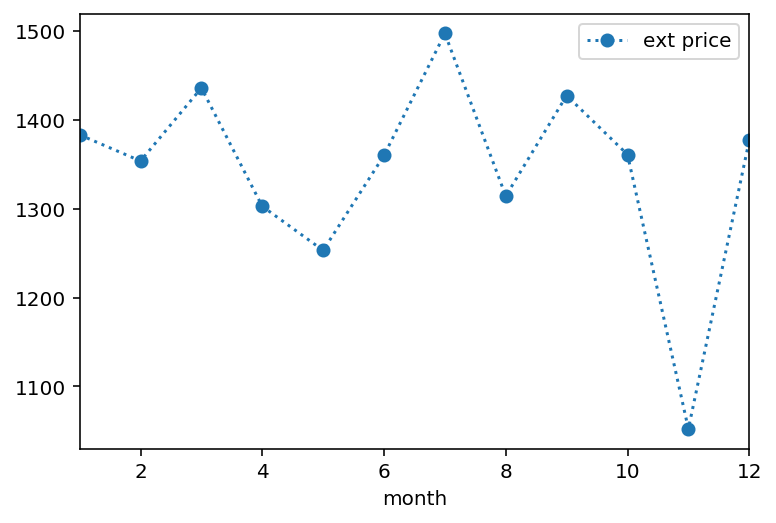

```python
data_time.plot(x='month', y='ext price',kind='line',marker='o', linestyle=':')
```

##### Color

Color is important when drawing a plot. It can be used to distinguish different categories or just to make the graph more pretty. When choosing a color, we suggest you this [reference](https://ant.design/docs/spec/colors-cn). Like the other two, `color` is also an optional key word argument in `plot` function.

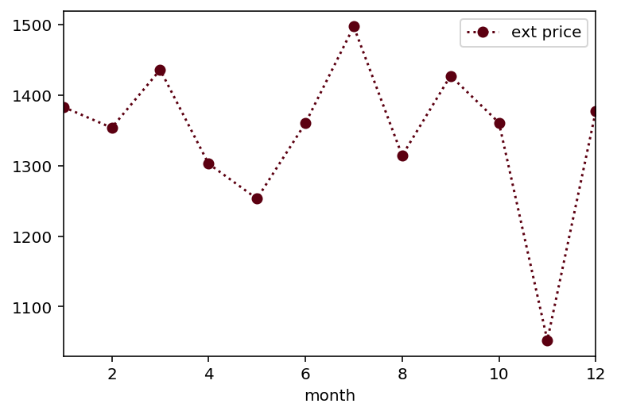

```python
data_time.plot(x='month', y='ext price',kind='line',marker='o', linestyle=':',color='#5c0011')
```

#### Customizing Axis

We are going to customize the axises of the first plot we drew.

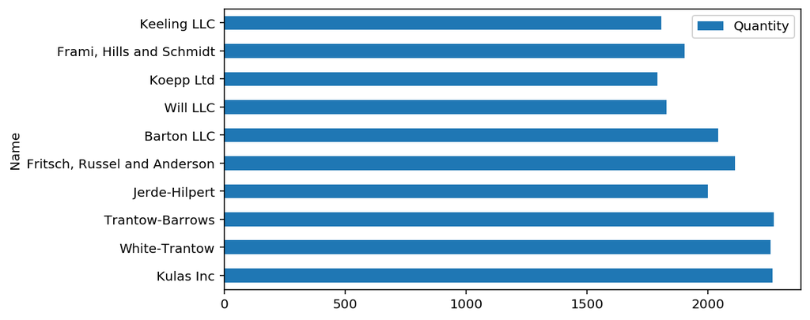

```python
fig
```

##### Axis Labels, ticks, gridlines and tick labels

Both of axis labels and tick labels are `text` objects. So we can use optional keyword argument to formate these labels. All available parameters can be found [here](https://matplotlib.org/3.1.1/api/text_api.html#matplotlib.text.Text).

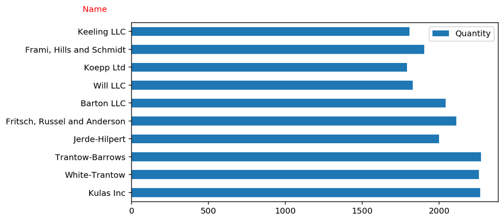

```python
# Set the axis lable
ax.yaxis.set_label_text('Name',rotation='0',color='r')

# Move the axis label to the top
ax.yaxis.set_label_coords(-0.1,1.05)

fig
```

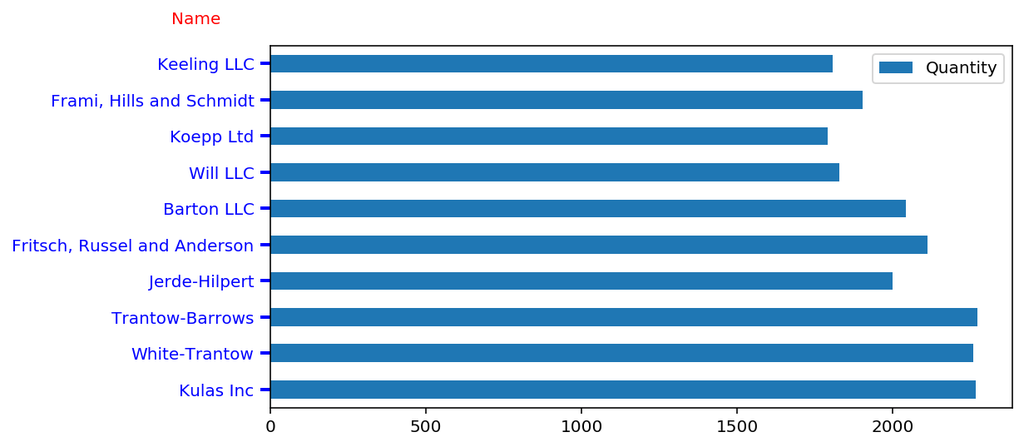

```python
# Only show ticks on the left and bottom spines
ax.yaxis.set_ticks_position('left')
ax.xaxis.set_ticks_position('bottom')

# Formate tick labels and grid lines
ax.yaxis.set_tick_params(direction='out', length=6, width=2, colors='b')

fig
```

Grid lines are `Line2D` object, so we can use optional keyword arguments to formate the line. All available parameters can be found [here](https://matplotlib.org/api/_as_gen/matplotlib.lines.Line2D.html#matplotlib.lines.Line2D).

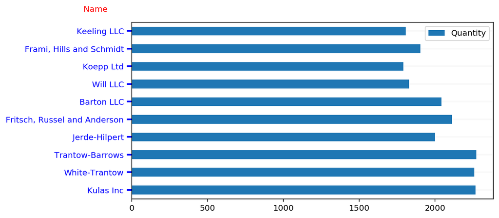

```python
# Show grid lines
ax.set_axisbelow(True)
ax.yaxis.grid(True,color='#f5f5f5', linestyle='-', linewidth=2, alpha=0.5)

fig
```

Other attributes and methods for axis and ticks can be found [here](https://matplotlib.org/api/axis_api.html#ticks-tick-labels-and-offset-text). Another way to change the formate of tickers is to use `ax.tick_params()` method. [Reference](https://matplotlib.org/api/_as_gen/matplotlib.axes.Axes.tick_params.html)

##### Spines

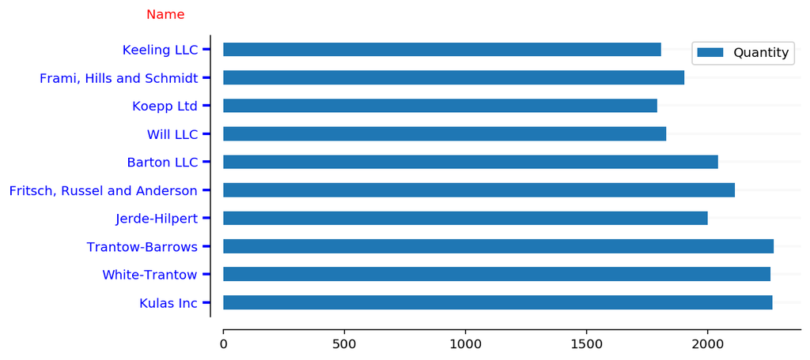

```python
# Move left and bottom spines outward by 10 points
ax.spines['left'].set_position(('outward', 10))
ax.spines['bottom'].set_position(('outward', 10))
# Hide the right and top spines
ax.spines['right'].set_visible(False)
ax.spines['top'].set_visible(False)

fig
```

##### Legend

Remove a legend

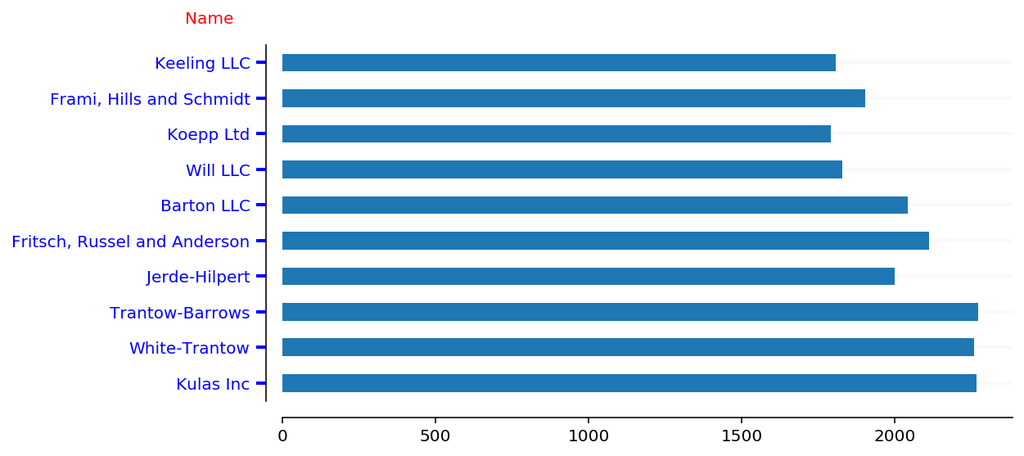

```python
legend = ax.get_legend()
legend.remove()
fig
```

Add a legend

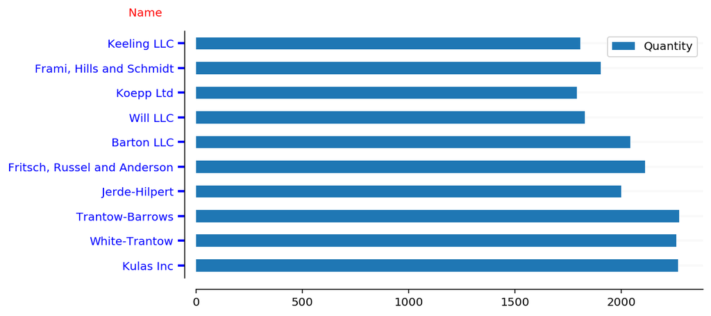

```python
ax.legend(['Quantity'],loc='best')
fig
```